# Question 6: Does the number of the case change along with the area?

# Data Munging

```r
library(readxl)
library(caret)
library(MASS)
library(tidyverse)
```

```r
data <- read_excel('311_Cases_cleaned.xlsx')
data$neighborhood <- as.factor(data$neighborhood)
head(data)
```

```
# A tibble: 6 × 27
   ...1 neighborhood  year mobile.dumm case       month request notes photo.dumm
  <dbl> <fct>        <dbl>       <dbl> <chr>      <chr> <chr>   <chr>      <dbl>
1     1 Bayview       2012           1 Street an… Sept… Genera… Case…          0
2     2 Bayview       2012           0 Street an… Dece… Bulky … Case…          0
3     3 Bayview       2012           1 Street an… Augu… Genera… Case…          0
4     4 Bayview       2012           0 Street an… Octo… Genera… Case…          0
5     5 Bayview       2012           0 Abandoned… March Abando… DPT …          0
6     6 Bayview       2012           0 Streetlig… Dece… Street… Case…          0
# ℹ 18 more variables: income <dbl>, population <dbl>, num_cases <dbl>,
#   white <dbl>, black <dbl>, asian <dbl>, resolution_time <chr>, agency <chr>,
#   resolution_rate <dbl>, CaseID <dbl>, latitude <dbl>, longitude <dbl>,
#   date <chr>, case_29 <chr>, registered <dbl>, turnout <dbl>,
#   turnout_one_lag <dbl>, turnout_two_lag <dbl>
```

```r
# Create a contingency table shows the count of each case type in each neighborhood
case_counts <- xtabs(~ case + neighborhood, data = data)
head(case_counts)
```

```
                            neighborhood
case                         Bayview Bernal Heights Chinatown Excelsior
  311 External Request            58             82        42        65
  Abandoned Vehicle             2175           4810        33      1246
  Blocked Street or SideWalk      84            201       126       132
  Catch Basin Maintenance         38             50        28        17
  Color Curb                       0              1         0         2
  Construction Zone Permits        0              0         0         2
                            neighborhood
case                         Haight Ashbury Inner Richmond Inner Sunset Marina
  311 External Request                   22            173           80     49
  Abandoned Vehicle                     184           1466          494    447
  Blocked Street or SideWalk             69            268          206    157
  Catch Basin Maintenance                 8             93           34     23
  Color Curb                              0              2            1      3
  Construction Zone Permits               0              1            0      0
                            neighborhood
case                         Mission Noe Valley Outer Mission Outer Richmond
  311 External Request           327         35            22            185
  Abandoned Vehicle             1662       1342           457           2496
  Blocked Street or SideWalk     908        170            33            192
  Catch Basin Maintenance        105         40             4             48
  Color Curb                       5          1             0              1
  Construction Zone Permits        0          0             0              0
                            neighborhood
case                         Pacific Heights Portola Potrero Hill
  311 External Request                    70     245          116
  Abandoned Vehicle                      605    1205         1695
  Blocked Street or SideWalk             272      62          342
  Catch Basin Maintenance                 57      16           61
  Color Curb                               3       2            1
  Construction Zone Permits                0       0            0
                            neighborhood
case                         Presidio Heights Seacliff South of Market
  311 External Request                      9       18             331
  Abandoned Vehicle                       230      824             904
  Blocked Street or SideWalk               97        7            1199
  Catch Basin Maintenance                  18       10             148
  Color Curb                                0        0               1
  Construction Zone Permits                 0        0               0
                            neighborhood
case                         Visitacion Valley Western Addition
  311 External Request                      25               73
  Abandoned Vehicle                        861              298
  Blocked Street or SideWalk                54              112
  Catch Basin Maintenance                    6               21
  Color Curb                                 0                0
  Construction Zone Permits                  0                0
```

```r
case_counts_df <- as.data.frame(case_counts)
names(case_counts_df) <- c('case_type', 'neighborhood', 'count')
head(case_counts_df)
```

```
                   case_type neighborhood count
1       311 External Request      Bayview    58
2          Abandoned Vehicle      Bayview  2175
3 Blocked Street or SideWalk      Bayview    84
4    Catch Basin Maintenance      Bayview    38
5                 Color Curb      Bayview     0
6  Construction Zone Permits      Bayview     0
```

# Model

```r
# Now fit the Negative Binomial model
# The glm.nb function fits a negative binomial model which can be more appropriate for over-dispersed count data
model <- glm.nb(count ~ neighborhood + case_type, data = case_counts_df)
summary(model)
```

```
Call:
glm.nb(formula = count ~ neighborhood + case_type, data = case_counts_df,
    init.theta = 1.983953755, link = log)

Coefficients:
                                                    Estimate Std. Error z value
(Intercept)                                          4.37247    0.19709  22.185
neighborhoodBernal Heights                           0.39775    0.16098   2.471
neighborhoodChinatown                                0.02080    0.16324   0.127
neighborhoodExcelsior                               -0.08099    0.16386  -0.494
neighborhoodHaight Ashbury                          -0.69336    0.16752  -4.139
neighborhoodInner Richmond                           0.33945    0.16132   2.104
neighborhoodInner Sunset                            -0.20680    0.16462  -1.256
neighborhoodMarina                                  -0.09981    0.16397  -0.609
neighborhoodMission                                  1.71363    0.15392  11.133
neighborhoodNoe Valley                              -0.23924    0.16481  -1.452
neighborhoodOuter Mission                           -1.25747    0.17085  -7.360
neighborhoodOuter Richmond                           0.33575    0.16135   2.081
neighborhoodPacific Heights                          0.34054    0.16132   2.111
neighborhoodPortola                                 -0.10346    0.16399  -0.631
neighborhoodPotrero Hill                             0.82576    0.15847   5.211
neighborhoodPresidio Heights                        -1.33223    0.17130  -7.777
neighborhoodSeacliff                                -2.15708    0.17656 -12.217
neighborhoodSouth of Market                          1.94830    0.15293  12.740
neighborhoodVisitacion Valley                       -0.88911    0.16868  -5.271
neighborhoodWestern Addition                         0.09381    0.16280   0.576
case_typeAbandoned Vehicle                           2.85863    0.22682  12.603
case_typeBlocked Street or SideWalk                  0.67785    0.22781   2.976
case_typeCatch Basin Maintenance                    -0.87257    0.23157  -3.768
case_typeColor Curb                                 -4.48862    0.32238 -13.924
case_typeConstruction Zone Permits                  -6.55813    0.61679 -10.633
case_typeDamaged Property                            1.77707    0.22707   7.826
case_typeDPW Volunteer Programs                     -4.44517    0.31938 -13.918
case_typeEncampments                                 2.14602    0.22695   9.456
case_typeGeneral Request - AGING ADULT SERVICES     -7.81443    1.06771  -7.319
case_typeGeneral Request - ANIMAL CARE CONTROL      -0.69772    0.23084  -3.023
case_typeGeneral Request - ART COMMISSION           -4.55967    0.32747 -13.924
case_typeGeneral Request - ASSESSOR RECORDER        -5.43334    0.41303 -13.155
case_typeGeneral Request - BOARD OF SUPERVISORS     -4.48027    0.32179 -13.923
case_typeGeneral Request - BUILDING INSPECTION      -0.36100    0.22972  -1.571
```

[output cut: 151 more lines]

```
---
Signif. codes:  0 '***' 0.001 '**' 0.01 '*' 0.05 '.' 0.1 ' ' 1

(Dispersion parameter for Negative Binomial(1.984) family taken to be 1)

    Null deviance: 21338.9  on 1459  degrees of freedom
Residual deviance:  1269.7  on 1368  degrees of freedom
AIC: 9291.8

Number of Fisher Scoring iterations: 1

              Theta:  1.984
          Std. Err.:  0.108

 2 x log-likelihood:  -9105.846
```

Positive coefficient like Mission has a coefficient of 1.71363, suggesting that being in the Mission neighborhood is associated with an increase in case counts compared to the baseline neighborhood Negative coefficient like Seacliff has a coefficient of -2.15708, indicating fewer cases compared to the baseline neighborhood

Many of the neighborhoods and case types have significant p-values, indicating strong evidence against the null hypothesis.

Areas like Mission and South of Market show a positive impact on case counts, which could indicate higher activity or reporting rates in these areas. In contrast, areas like Seacliff and Presidio Heights show a negative impact, suggesting lower case counts.

Certain types of cases, such as Graffiti and Street and Sidewalk Cleaning, have high positive coefficients, indicating these are common complaints across the city. Conversely, case types like General Request - AGING ADULT SERVICES and General Request - CITY ATTORNEY have large negative coefficients, suggesting these are less frequently reported or specific to fewer areas.

```r
library(ggplot2)
library(ggmap)
```

```r
data_2012_cleaning <- subset(data, year == 2012 & case == "Street and Sidewalk Cleaning")
```

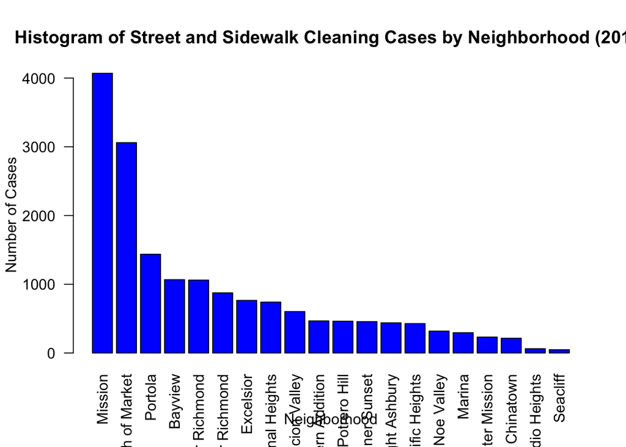

```r
case_counts <- table(data_2012_cleaning$neighborhood)

# Sorting the neighborhoods by the number of cases to make the histogram more informative
sorted_counts <- sort(case_counts, decreasing = TRUE)

barplot(sorted_counts,
        main = "Histogram of Street and Sidewalk Cleaning Cases by Neighborhood (2012)",
        xlab = "Neighborhood",
        ylab = "Number of Cases",
        las = 2, # makes the labels perpendicular to axis
        col = "blue")
```